title: “NYPDShootingReport” output: html_document date: “2023-03-07”

## Step 0: Import Library

```r
# install.packages("tidyverse")
library(tidyverse)
library(lubridate)
```

## Step 1: Load Data

- `read_csv()` reads comma delimited files

```r
df = read_csv("https://data.cityofnewyork.us/api/views/833y-fsy8/rows.csv?accessType=DOWNLOAD")
head(df)
```

```
## # A tibble: 6 × 19
##   INCIDE…¹ OCCUR…² OCCUR…³ BORO  PRECI…⁴ JURIS…⁵ LOCAT…⁶ STATI…⁷ PERP_…⁸ PERP_…⁹
##      <dbl> <chr>   <time>  <chr>   <dbl>   <dbl> <chr>   <lgl>   <chr>   <chr>
## 1   2.36e8 11/11/… 15:04   BROO…      79       0 <NA>    FALSE   <NA>    <NA>
## 2   2.31e8 07/16/… 22:05   BROO…      72       0 <NA>    FALSE   45-64   M
## 3   2.31e8 07/11/… 01:09   BROO…      79       0 <NA>    FALSE   <18     M
## 4   2.38e8 12/11/… 13:42   BROO…      81       0 <NA>    FALSE   <NA>    <NA>
## 5   2.24e8 02/16/… 20:00   QUEE…     113       0 <NA>    FALSE   <NA>    <NA>
## 6   2.28e8 05/15/… 04:13   QUEE…     113       0 <NA>    TRUE    <NA>    <NA>
## # … with 9 more variables: PERP_RACE <chr>, VIC_AGE_GROUP <chr>, VIC_SEX <chr>,
## #   VIC_RACE <chr>, X_COORD_CD <dbl>, Y_COORD_CD <dbl>, Latitude <dbl>,
## #   Longitude <dbl>, Lon_Lat <chr>, and abbreviated variable names
## #   ¹INCIDENT_KEY, ²OCCUR_DATE, ³OCCUR_TIME, ⁴PRECINCT, ⁵JURISDICTION_CODE,
## #   ⁶LOCATION_DESC, ⁷STATISTICAL_MURDER_FLAG, ⁸PERP_AGE_GROUP, ⁹PERP_SEX
```

## Step 2: Tidy and Transform Data

```r
df_2 = df %>% select(INCIDENT_KEY,
                   OCCUR_DATE,
                   OCCUR_TIME,
                   BORO,
                   STATISTICAL_MURDER_FLAG,
                   PERP_AGE_GROUP,
                   PERP_SEX,
                   PERP_RACE,
                   VIC_AGE_GROUP,
                   VIC_SEX,
                   VIC_RACE,
                   Latitude,
                   Longitude)
# Return the column name along with the missing values
lapply(df_2, function(x) sum(is.na(x)))
```

```
## $INCIDENT_KEY
## [1] 0
##
## $OCCUR_DATE
## [1] 0
##
## $OCCUR_TIME
## [1] 0
##
## $BORO
## [1] 0
##
## $STATISTICAL_MURDER_FLAG
## [1] 0
##
## $PERP_AGE_GROUP
## [1] 9344
##
## $PERP_SEX
## [1] 9310
##
## $PERP_RACE
## [1] 9310
##
## $VIC_AGE_GROUP
## [1] 0
##
## $VIC_SEX
## [1] 0
##
## $VIC_RACE
## [1] 0
##
## $Latitude
## [1] 0
##
## $Longitude
## [1] 0
```

Data is missing within some of the columns within the the CSV file imported. There is a lot of data which isn’t listed, such as perpetrator ages, sex, and race. This could be due to unavailable data regarded specific cases of shootings. This is handled by passing through all these unavailable groups into an “Unknown” group. This is done because we need to make sure this data is properly handled, as it could contain important information to the whole scope of our analysis.

Data Types:

- **INCIDENT_KEY** should be treated as a string.
- **BORO** should be treated as a factor.
- **PERP_AGE_GROUP** should be treated as a factor.
- **PERP_SEX** should be treated as a factor.
- **PERP_RACE** should be treated as a factor.
- **VIC_AGE_GROUP** should be treated as a factor.
- **VIC_SEX** should be treated as a factor.
- **VIC_RACE** should be treated as a factor.

Race, Sex, Age Group, and Boro are all treated as factors. Incident Key should be treated as a string.

```r
# Tidy and transform data
df_2 = df_2 %>%
  replace_na(list(PERP_AGE_GROUP = "Unknown", PERP_SEX = "Unknown", PERP_RACE = "Unknown"))
# Remove extreme values in data
df_2 = subset(df_2, PERP_AGE_GROUP!="1020" & PERP_AGE_GROUP!="224" & PERP_AGE_GROUP!="940")
df_2$PERP_AGE_GROUP = recode(df_2$PERP_AGE_GROUP, UNKNOWN = "Unknown")
df_2$PERP_SEX = recode(df_2$PERP_SEX, U = "Unknown")
df_2$PERP_RACE = recode(df_2$PERP_RACE, UNKNOWN = "Unknown")
df_2$VIC_SEX   = recode(df_2$VIC_SEX, U = "Unknown")
df_2$VIC_RACE   = recode(df_2$VIC_RACE, UNKNOWN = "Unknown")
df_2$INCIDENT_KEY = as.character(df_2$INCIDENT_KEY)
df_2$BORO = as.factor(df_2$BORO)
df_2$PERP_AGE_GROUP = as.factor(df_2$PERP_AGE_GROUP)
df_2$PERP_SEX = as.factor(df_2$PERP_SEX)
df_2$PERP_RACE = as.factor(df_2$PERP_RACE)
df_2$VIC_AGE_GROUP = as.factor(df_2$VIC_AGE_GROUP)
df_2$VIC_SEX = as.factor(df_2$VIC_SEX)
df_2$VIC_RACE = as.factor(df_2$VIC_RACE)
# Return summary statistics
summary(df_2)
```

```
##  INCIDENT_KEY        OCCUR_DATE         OCCUR_TIME                  BORO
##  Length:25593       Length:25593       Length:25593      BRONX        : 7400
##  Class :character   Class :character   Class1:hms        BROOKLYN     :10364
##  Mode  :character   Mode  :character   Class2:difftime   MANHATTAN    : 3265
##                                        Mode  :numeric    QUEENS       : 3828
##                                                          STATEN ISLAND:  736
##
##
##  STATISTICAL_MURDER_FLAG PERP_AGE_GROUP     PERP_SEX
##  Mode :logical           <18    : 1463   F      :  371
##  FALSE:20665             18-24  : 5844   M      :14413
##  TRUE :4928              25-44  : 5202   Unknown:10809
##                          45-64  :  535
##                          65+    :   57
##                          Unknown:12492
##
##                           PERP_RACE     VIC_AGE_GROUP      VIC_SEX
##  AMERICAN INDIAN/ALASKAN NATIVE:    2   <18    : 2681   F      : 2403
##  ASIAN / PACIFIC ISLANDER      :  141   18-24  : 9603   M      :23179
##  BLACK                         :10667   25-44  :11384   Unknown:   11
##  BLACK HISPANIC                : 1203   45-64  : 1698
##  Unknown                       :11146   65+    :  167
##  WHITE                         :  272   UNKNOWN:   60
##  WHITE HISPANIC                : 2162
##                            VIC_RACE        Latitude       Longitude
##  AMERICAN INDIAN/ALASKAN NATIVE:    9   Min.   :40.51   Min.   :-74.25
##  ASIAN / PACIFIC ISLANDER      :  354   1st Qu.:40.67   1st Qu.:-73.94
##  BLACK                         :18280   Median :40.70   Median :-73.92
##  BLACK HISPANIC                : 2485   Mean   :40.74   Mean   :-73.91
##  Unknown                       :   65   3rd Qu.:40.82   3rd Qu.:-73.88
##  WHITE                         :  660   Max.   :40.91   Max.   :-73.70
##  WHITE HISPANIC                : 3740
```

## Step 3: Add Visualizations and Analysis

**Research Question**

1. Which Area of New York has the most number of incidents? How many of these incidents were considered Murder Cases?

Brooklyn had the highest amount of incidents. Bronx had the second highest amount of incidents. Queens had the third highest amount of incidents. The murder cases, also followed the same structure going: Brooklyn, Bronx, and Queens.

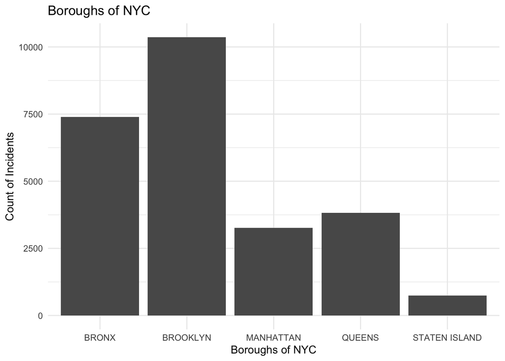

```r
g <- ggplot(df_2, aes(x = BORO)) +
  geom_bar() +
  labs(title = "Boroughs of NYC",
       x = "Boroughs of NYC",
       y = "Count of Incidents") +
  theme_minimal()
g
```

```r
table(df_2$BORO, df_2$STATISTICAL_MURDER_FLAG)
```

```
##
##                 FALSE TRUE
##   BRONX          5983 1417
##   BROOKLYN       8344 2020
##   MANHATTAN      2691  574
##   QUEENS         3066  762
##   STATEN ISLAND   581  155
```

2. Which days and time in NYC are people the most targeted for crime?

Weekends in NYC have the most chances of incidents, this is because incidents historically happen in the evening or around night. It is advised to stay at home during late hours of the weekend in order to minimize chances of becoming a victim of crime. The other highest points according to the data, would be considered Monday and Friday, both days which directly before or after a weekend respectively. The safest hours for a lesser amount of incidents would anywhere from 5AM-10AM. The hours for a higher chance of incidents would occur anywhere from 10PM-4AM.

```r
df_2$OCCUR_DAY = mdy(df_2$OCCUR_DATE)
df_2$OCCUR_DAY = wday(df_2$OCCUR_DAY, label = TRUE)
df_2$OCCUR_HOUR = hour(hms(as.character(df_2$OCCUR_TIME)))
df_3 = df_2 %>%
  group_by(OCCUR_DAY) %>%
  count()
df_4 = df_2 %>%
  group_by(OCCUR_HOUR) %>%
  count()
```

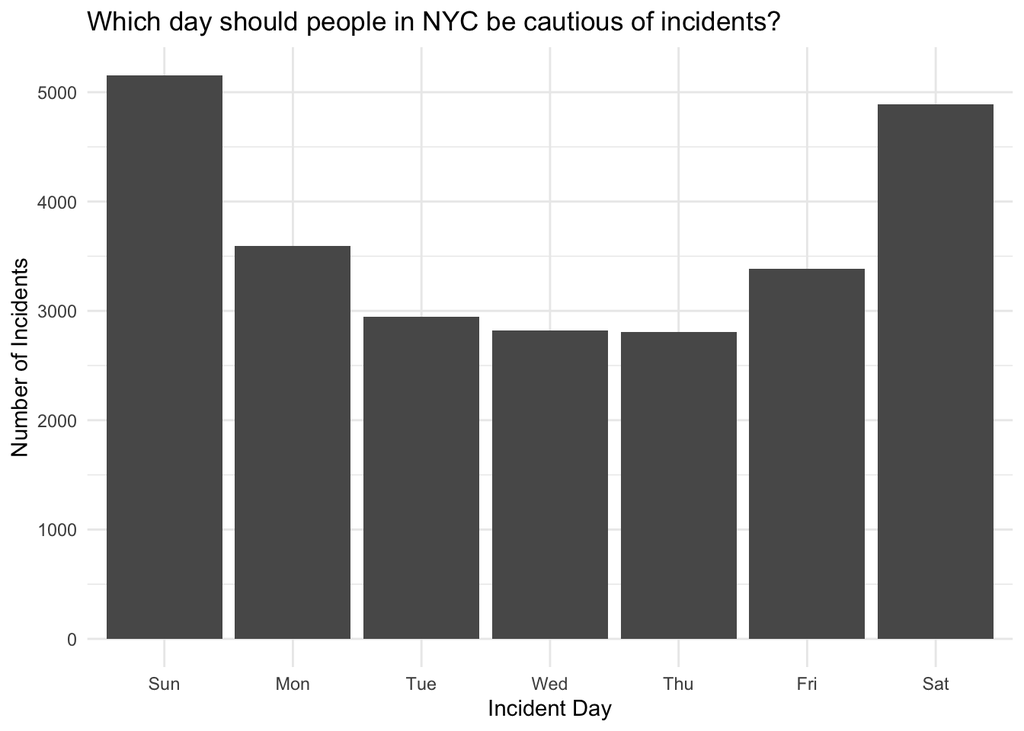

```r
g <- ggplot(df_3, aes(x = OCCUR_DAY, y = n)) +
  geom_col() +
  labs(title = "Which day should people in NYC be cautious of incidents?",
       x = "Incident Day",
       y = "Number of Incidents") +
  theme_minimal()
g
```

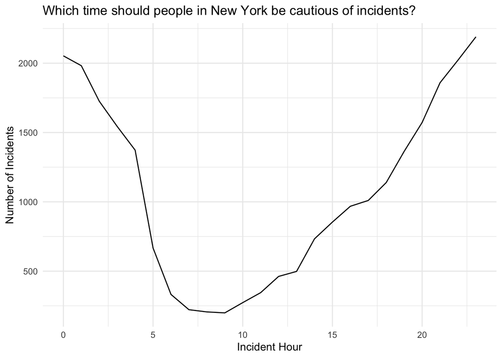

```r
g <- ggplot(df_4, aes(x = OCCUR_HOUR, y = n)) +
  geom_line() +
  labs(title = "Which time should people in New York be cautious of incidents?",
       x = "Incident Hour",
       y = "Number of Incidents") +
  theme_minimal()
g
```

Looking at this data, we should go deeper and investigate the ages and genders of perps. Creating a profile for the perpetrators and victims could be useful for a more deeper and thorough analysis.

3. The Profile of Perpetrators and Victims

A large number of incidents in the age group of 25-44 and 18-24 exists within the data. Black and White Hispanic neighborhoods were higher in the number of incidents in Boroughs of NYC when compared to White and Asian/Pacific Islander. There are significantly more incidents with Male than those of Female as well.

```r
table(df_2$PERP_AGE_GROUP, df_2$VIC_AGE_GROUP)
```

```
##
##            <18 18-24 25-44 45-64  65+ UNKNOWN
##   <18      445   584   353    70    9       2
##   18-24    742  2607  2141   305   37      12
##   25-44    247  1417  3033   431   40      34
##   45-64     19    62   290   148   11       5
##   65+        0     1    23    23   10       0
##   Unknown 1228  4932  5544   721   60       7
```

```r
table(df_2$PERP_SEX, df_2$VIC_SEX)
```

```
##
##               F     M Unknown
##   F          58   312       1
##   M        1540 12867       6
##   Unknown   805 10000       4
```

```r
table(df_2$PERP_RACE, df_2$VIC_RACE)
```

```
##
##                                  AMERICAN INDIAN/ALASKAN NATIVE
##   AMERICAN INDIAN/ALASKAN NATIVE                              0
##   ASIAN / PACIFIC ISLANDER                                    0
##   BLACK                                                       4
##   BLACK HISPANIC                                              0
##   Unknown                                                     5
##   WHITE                                                       0
##   WHITE HISPANIC                                              0
##
##                                  ASIAN / PACIFIC ISLANDER BLACK BLACK HISPANIC
##   AMERICAN INDIAN/ALASKAN NATIVE                        0     2              0
##   ASIAN / PACIFIC ISLANDER                             43    51             13
##   BLACK                                               135  8470            749
##   BLACK HISPANIC                                       17   481            320
##   Unknown                                             113  8523            999
##   WHITE                                                11    34             21
##   WHITE HISPANIC                                       35   719            383
##
##                                  Unknown WHITE WHITE HISPANIC
##   AMERICAN INDIAN/ALASKAN NATIVE       0     0              0
##   ASIAN / PACIFIC ISLANDER             0    11             23
##   BLACK                               24   183           1102
##   BLACK HISPANIC                       5    34            346
##   Unknown                             24   187           1295
##   WHITE                                1   156             49
##   WHITE HISPANIC                      11    89            925
```

4.Logistic regression model to predict if the incident is a murder? (Analysis)

Logistic regression models to estimate the probability that a murder case belongs to a particular profile, location, or date & time will be used within this analysis. The output shows the coefficients, their standard errors, the z-statistic, and the associated p-values.

```r
# Logistics Regression
glm.fit <- glm(STATISTICAL_MURDER_FLAG ~ PERP_RACE + PERP_SEX + PERP_AGE_GROUP + OCCUR_HOUR + OCCUR_DAY + Latitude + Longitude, data = df_2, family = binomial)
summary(glm.fit)
```

```
##
## Call:
## glm(formula = STATISTICAL_MURDER_FLAG ~ PERP_RACE + PERP_SEX +
##     PERP_AGE_GROUP + OCCUR_HOUR + OCCUR_DAY + Latitude + Longitude,
##     family = binomial, data = df_2)
##
## Deviance Residuals:
##     Min       1Q   Median       3Q      Max
## -1.9208  -0.6805  -0.6070  -0.2244   2.9329
##
## Coefficients:
##                                    Estimate Std. Error z value Pr(>|z|)
## (Intercept)                       41.010992  86.674411   0.473 0.636098
## PERP_RACEASIAN / PACIFIC ISLANDER  9.970625  84.227789   0.118 0.905769
## PERP_RACEBLACK                     9.522565  84.227590   0.113 0.909985
## PERP_RACEBLACK HISPANIC            9.400786  84.227620   0.112 0.911131
## PERP_RACEUnknown                   9.048532  84.227842   0.107 0.914448
## PERP_RACEWHITE                    10.152437  84.227687   0.121 0.904059
## PERP_RACEWHITE HISPANIC            9.679434  84.227601   0.115 0.908509
## PERP_SEXM                         -0.190155   0.120994  -1.572 0.116043
## PERP_SEXUnknown                    2.429474   0.268105   9.062  < 2e-16 ***
## PERP_AGE_GROUP18-24                0.171250   0.075386   2.272 0.023108 *
## PERP_AGE_GROUP25-44                0.505662   0.075080   6.735 1.64e-11 ***
## PERP_AGE_GROUP45-64                0.837458   0.114547   7.311 2.65e-13 ***
## PERP_AGE_GROUP65+                  1.008423   0.282806   3.566 0.000363 ***
## PERP_AGE_GROUPUnknown             -2.240328   0.171340 -13.075  < 2e-16 ***
## OCCUR_HOUR                        -0.002730   0.001978  -1.380 0.167503
## OCCUR_DAY.L                       -0.057112   0.039780  -1.436 0.151090
## OCCUR_DAY.Q                       -0.085781   0.042774  -2.005 0.044915 *
## OCCUR_DAY.C                       -0.056694   0.043019  -1.318 0.187541
## OCCUR_DAY^4                       -0.022589   0.043831  -0.515 0.606290
## OCCUR_DAY^5                       -0.009570   0.046033  -0.208 0.835305
## OCCUR_DAY^6                       -0.059742   0.047397  -1.260 0.207499
## Latitude                          -0.434742   0.190205  -2.286 0.022274 *
## Longitude                          0.461736   0.241068   1.915 0.055445 .
## ---
## Signif. codes:  0 '***' 0.001 '**' 0.01 '*' 0.05 '.' 0.1 ' ' 1
##
## (Dispersion parameter for binomial family taken to be 1)
##
##     Null deviance: 25076  on 25592  degrees of freedom
## Residual deviance: 24150  on 25570  degrees of freedom
## AIC: 24196
##
## Number of Fisher Scoring iterations: 9
```

## Additional Resources

- [NYPD Shooting Incident Data (Historic) - CKAN](https://catalog.data.gov/dataset/nypd-shooting-incident-data-historic)
- [City sees drop in shootings and murders, but overall crime rises: NYPD data](https://www.ny1.com/nyc/all-boroughs/news/2022/11/03/october-2022-nypd-crime-data)
- [Major Crimes Rose 22 Percent in New York City, Even as Shootings Fell - NY Times](https://www.nytimes.com/2023/01/05/nyregion/new-york-crime-stats.html) Footer